# EZBHDDM: Short report

Adriana F. Chávez De la Peña

2024-12-09

# Welcome!

**This short report contains the code to replicate a full parameter-recovery simulation study**.

Once a number of participants (`nParticipants`) and trials (`nTrials`) have been selected, we generate data from a diffusion process with individual parameter values sampled from parental distributions. The hierarchical means and standard deviations are either sampled from the same prior distributions later used for estimation (`fromPrior = TRUE`) or from suited uniform distributions (`fromPrior = FALSE`). If `fromPrior = FALSE`, the hierarchical standard deviations are fixed. Once trial-level data has been generated, we compute the EZ-summary statistics and obtain estimations for the hierarchical mean parameters using our Hierarchical Bayesian EZ-DDM model. This parameter-recovery test is repeated over the course of many iterations (`nDatasets`).

# Introduction

The Simple Drift diffusion model describes jointly ($\mathbf{Y}$) the choices and response times (RTs) observed in binary decision tasks using a Wiener likelihood with three parameters:

$$\begin{align*}
\mathbf{Y} \sim \mbox{DDM}\bigl(\alpha, \nu, \tau \bigl)
\end{align*}$$

$$\begin{align*}
PC &= \frac{1}{\exp(-\alpha\nu)+1}\\
MRT &= \tau +
\frac{\alpha}{2\nu}\frac{\exp(-\alpha\nu)-1}{\exp(-\alpha\nu)+1}\\
PRT &=
\frac{\alpha}{2\nu^3}\{\frac{1-2\alpha\nu\exp(-\alpha\nu)-\exp(-\alpha\nu)^2}{(\exp(-\alpha\nu)+1)^2}\}
\end{align*}$$

We present a probabilistic formulation of the EZ-DDM, that allows the user to build Hierarchical Bayesian extensions using the following three summary statistics:

$$\begin{align*}
Y &\Rightarrow \{\dot{T}, \dot{M}, \dot{V}\}\\
\end{align*}$$

$$\begin{align*}
PC &= \frac{1}{\exp(-\alpha\nu)+1}\\
MRT &= \tau +
\frac{\alpha}{2\nu}\frac{\exp(-\alpha\nu)-1}{\exp(-\alpha\nu)+1}\\
PRT &=
\frac{\alpha}{2\nu^3}\{\frac{1-2\alpha\nu\exp(-\alpha\nu)-\exp(-\alpha\nu)^2}{(\exp(-\alpha\nu)+1)^2}\}
\end{align*}$$

where $PC$ is the Proportion of Correct responses, and $MRT$ and $PRT$ are the mean and precission (i.e., the inverse of the variance) of the RT distribution. Importantly, inverting this system of equations allows us to obtain closed-form parameter estimators from these summary statistics.

Here, we present a probabilistic formulation of the EZ-DDM that allows for the hyper-efficient construction of Hierarchical Bayesian extensions that explain the variability across parameters as a function of predictors, or higher-level structures of interest. Our probabilistic model is built using what we know about the sampling distributions of the summary statistics used in the EZ-DDM:

$$\begin{align*}
\dot{T} &\sim \mbox{Binomial}(PC,N)\\
\dot{V} &\sim \mbox{Normal}(\frac{1}{PRT},\frac{N-1}{2(PRT)^2})\\
\dot{M} &\sim \mbox{Normal}(MRT, PRT \times N)\\
\end{align*}$$

where the normal distributions are parametrized in terms of their mean and precision.

**In our paper, we present six simulation studies** testing the parameter recovery of the hierarchical means of the drift rate, boundary separation and nondecision time parameter, and the regression coefficient parameter $\beta$, across different designs. In this script we introduce a single function `HDDM_runSims()` that executes a script for conducting a full simulation study with `nParticipants`, `nTrials`, `nDatasets`.

### Loading up the necessary functions

```r
#### We will load all function scripts nested in the./code/functions/ directory
for(archive in dir(here("./code/functions/"))){    source(paste(here("./code/functions/"),archive,sep=""))     }
#### We load the higher-level functions that call individual functions to do specific routines
source(here("./code/scripts/HDDM_setup.R"))      # Sample parameters and generate data
source(here("./code/scripts/HDDM_runJAGS.R"))    # Run JAGS
source(here("./code/scripts/HDDM_runSims.R"))    # Run full simulation study
```

# Define general settings for our simulation study

```r
########################
###  General design  ###
########################
nParticipants <- 40
nTrials   <- 160
nDatasets <- 200

########################
###  JAGS variables  ###
########################
n.iter   = 2000
n.chains = 4
n.burnin = 500
n.thin   = 1

##########################################
# Preferences for running the simulation #
##########################################
# Are true parameter values generated from the prior?
fromPrior = TRUE
# Where we storing the results (i.e., samples and JAGS model file)
store_results_to <- here("./simulations/shortReport_results/")
# Show some results on screen (i.e. the chains for one of the iterations)
Show = TRUE
# Do we want to track ALL parameters or just the hierarchical means?
track_allParameters = FALSE
# Verify that there are no Rhats > 1.05
rhatCheck = TRUE
# Do we want to re-do iterations with a bad R-hat
redo_if_bad_rhat = TRUE
```

# Run a simple simulation!

We can run the `HDDM_runSims()` function (stored at “./code/scripts/HDDM_runSims.R”) to run a full simulation study with the characteristics specified above. We will start with `modelType="hierarchical"`, which is the simplest design available, where all individual-level parameters are generated (and modeled) as samples from a parent normal distribution.

$$\begin{align*}
\nu_p \sim \mtext{Normal}(\mu_\nu, \lambda_\nu)\\
\alpha_p \sim \mtext{Normal}(\mu_\alpha, \lambda_\alpha)\\
\tau_p \sim \mtext{Normal}(\mu_\tau, \lambda_\tau)
\end{align*}$$

```r
simH <- HDDM_runSims(nParticipants = nParticipants,
                     nTrials = nTrials,
                     nDatasets = nDatasets,
                     n.iter = n.iter,
                     n.chains = n.chains,
                     n.burnin = n.burnin,
                     n.thin = n.thin,
                     fromPrior = fromPrior,
                     output.folder = store_results_to,
                     Show = Show,
                     track_allParameters = track_allParameters,
                     rhatCheck = rhatCheck,
                     redo_if_bad_rhat = redo_if_bad_rhat,
                     modelType = "hierarchical")   # Simple HB-EZDDM
```

```
## This simulation had been run before.
## Loading stored results: COMPLETE!
##  Running this simulation study took  33.28333 minutes.
## ~~~~~~~~~~~~~~~~~~~~~~~~~~~~~~~~~~~~~~~~~~~~~~~~!!!
## R-hat check (Hierarchical mean parameters):
## No Rhat greater than 1.05
## ~~~~~~~~~~~~~~~~~~~~~~~~~~~~~~~~~~~~~~~~~~~~~~~~!!!
```

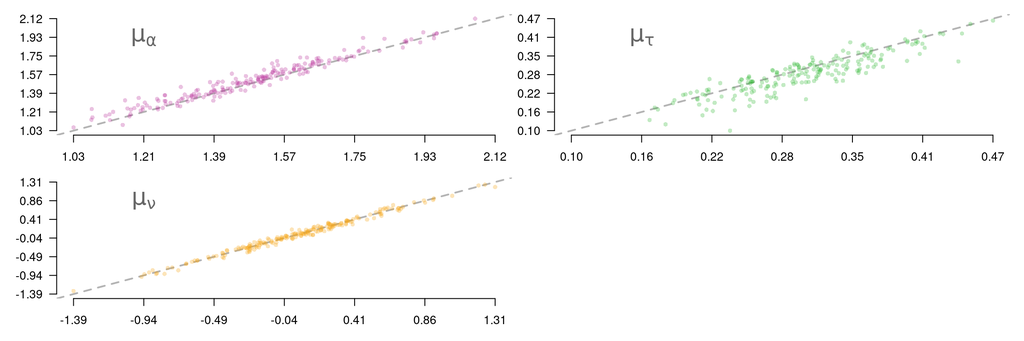

```r
plot_recovery(simH)
```

# Simulation studies with different designs

### Metaregression model

We model the individual-level drift rate parameter $\nu_p$ using a simple linear regression function, with a **continuous individual predictor** $X_p \in \left(0,1\right)$.

$$\begin{align*}
\nu_p \sim \mtext{Normal}(\mu_\nu + \beta X_p, \lambda_\nu)\\
\alpha_p \sim \mtext{Normal}(\mu_\alpha, \lambda_\alpha)\\
\tau_p \sim \mtext{Normal}(\mu_\tau, \lambda_\tau)
\end{align*}$$

```r
simM <- HDDM_runSims(nParticipants = nParticipants,
                     nTrials = nTrials,
                     nDatasets = nDatasets,
                     n.iter = n.iter,
                     n.chains = n.chains,
                     n.burnin = n.burnin,
                     n.thin = n.thin,
                     fromPrior = fromPrior,
                     output.folder = store_results_to,
                     Show = Show,
                     track_allParameters = track_allParameters,
                     rhatCheck = rhatCheck,
                     redo_if_bad_rhat = redo_if_bad_rhat,
                     modelType = "metaregression")
```

```
## This simulation had been run before.
## Loading stored results: COMPLETE!
##  Running this simulation study took  35.95 minutes.
## ~~~~~~~~~~~~~~~~~~~~~~~~~~~~~~~~~~~~~~~~~~~~~~~~!!!
## R-hat check (All parameters):
## No Rhat greater than 1.05
## ~~~~~~~~~~~~~~~~~~~~~~~~~~~~~~~~~~~~~~~~~~~~~~~~!!!
```

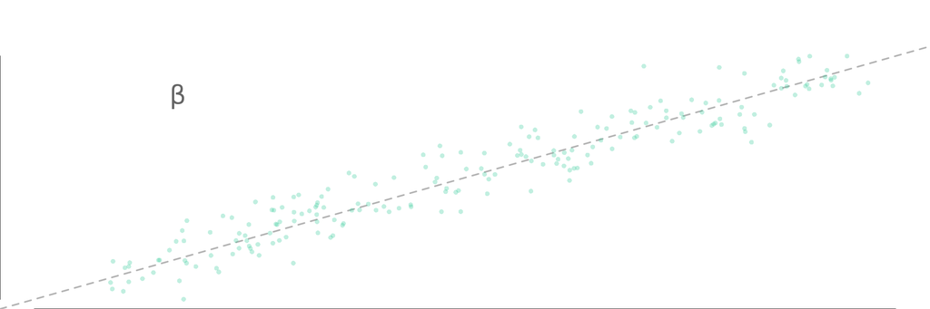

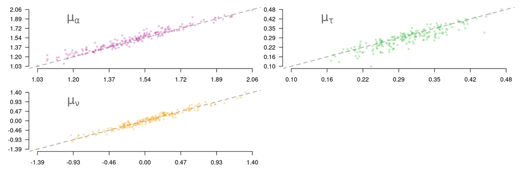

```r
plot_recovery(simM)
```

### T-test model

We model the individual-level drift rate parameter $\nu_p$ using a simple linear regression function, with a **dichotomous individual predictor** $X_p \in \left\{0,1\right\}$.

$$\begin{align*}
\nu_p \sim \mtext{Normal}(\mu_\nu + \beta X_p, \lambda_\nu)\\
\alpha_p \sim \mtext{Normal}(\mu_\alpha, \lambda_\alpha)\\
\tau_p \sim \mtext{Normal}(\mu_\tau, \lambda_\tau)
\end{align*}$$

```r
simT <- HDDM_runSims(nParticipants = nParticipants,
                     nTrials = nTrials,
                     nDatasets = nDatasets,
                     n.iter = n.iter,
                     n.chains = n.chains,
                     n.burnin = n.burnin,
                     n.thin = n.thin,
                     fromPrior = fromPrior,
                     output.folder = store_results_to,
                     Show = Show,
                     track_allParameters = track_allParameters,
                     rhatCheck = rhatCheck,
                     redo_if_bad_rhat = redo_if_bad_rhat,
                     modelType = "ttest")
```

```
## This simulation had been run before.
## Loading stored results: COMPLETE!
##  Running this simulation study took  36.6 minutes.
## ~~~~~~~~~~~~~~~~~~~~~~~~~~~~~~~~~~~~~~~~~~~~~~~~!!!
## R-hat check (All parameters):
## No Rhat greater than 1.05
## ~~~~~~~~~~~~~~~~~~~~~~~~~~~~~~~~~~~~~~~~~~~~~~~~!!!
```

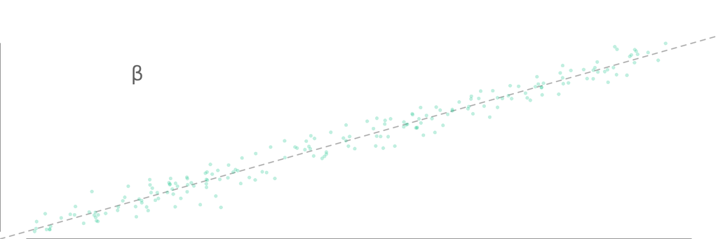

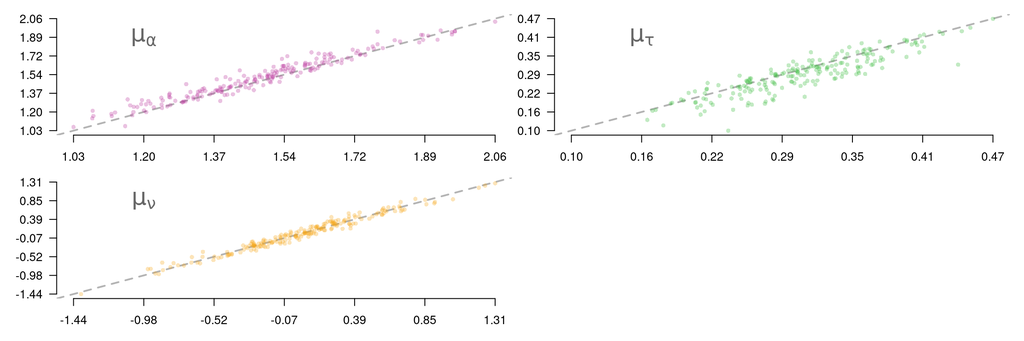

```r
plot_recovery(simT)
```

# Simulation studies with uniform generative distributions

All past simulation studies were conducted by using generative priors (i.e., the hierarchical mean and standard deviation parameters are sampled from the prior distributions used for inference).

By setting `fromPrior = FALSE`, our function allows to conduct simulation studies where the hierarchical mean parameters are extracted from suited uniform distributions, with the hierarchical standard deviations being fixed.

### Hierarchical model

```r
simH2 <- HDDM_runSims(nParticipants = nParticipants,
                     nTrials = nTrials,
                     nDatasets = nDatasets,
                     n.iter = n.iter,
                     n.chains = n.chains,
                     n.burnin = n.burnin,
                     n.thin = n.thin,
                     fromPrior = FALSE,
                     output.folder = store_results_to,
                     Show = Show,
                     track_allParameters = track_allParameters,
                     rhatCheck = rhatCheck,
                     redo_if_bad_rhat = redo_if_bad_rhat,
                     modelType = "hierarchical")
```

```
## This simulation had been run before.
## Loading stored results: COMPLETE!
##  Running this simulation study took  34.73333 minutes.
## ~~~~~~~~~~~~~~~~~~~~~~~~~~~~~~~~~~~~~~~~~~~~~~~~!!!
## R-hat check (Hierarchical mean parameters):
## No Rhat greater than 1.05
## ~~~~~~~~~~~~~~~~~~~~~~~~~~~~~~~~~~~~~~~~~~~~~~~~!!!
```

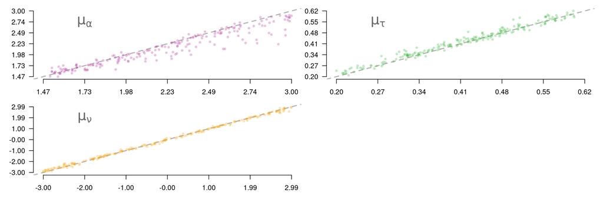

```r
plot_recovery(simH2)
```

### Metaregression model

```r
simM2 <- HDDM_runSims(nParticipants = nParticipants,
                     nTrials = nTrials,
                     nDatasets = nDatasets,
                     n.iter = n.iter,
                     n.chains = n.chains,
                     n.burnin = n.burnin,
                     n.thin = n.thin,
                     fromPrior = FALSE,
                     output.folder = store_results_to,
                     Show = Show,
                     track_allParameters = track_allParameters,
                     rhatCheck = rhatCheck,
                     redo_if_bad_rhat = redo_if_bad_rhat,
                     modelType = "metaregression")
```

```
## This simulation had been run before.
## Loading stored results: COMPLETE!
##  Running this simulation study took  37.2 minutes.
## ~~~~~~~~~~~~~~~~~~~~~~~~~~~~~~~~~~~~~~~~~~~~~~~~!!!
## R-hat check (All parameters):
## No Rhat greater than 1.05
## ~~~~~~~~~~~~~~~~~~~~~~~~~~~~~~~~~~~~~~~~~~~~~~~~!!!
```

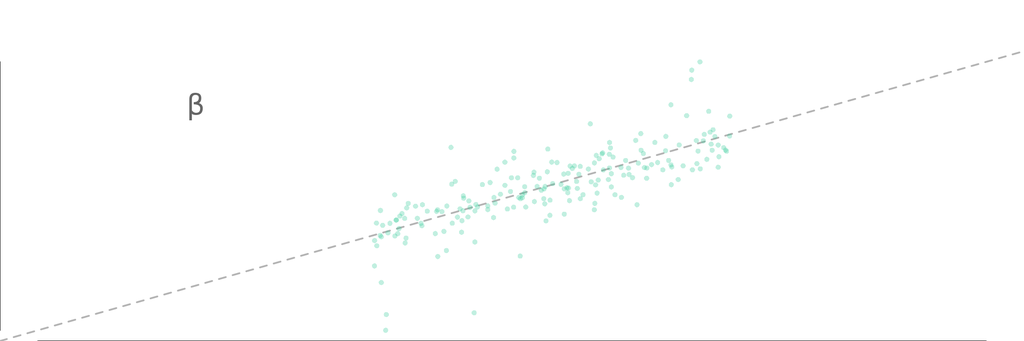

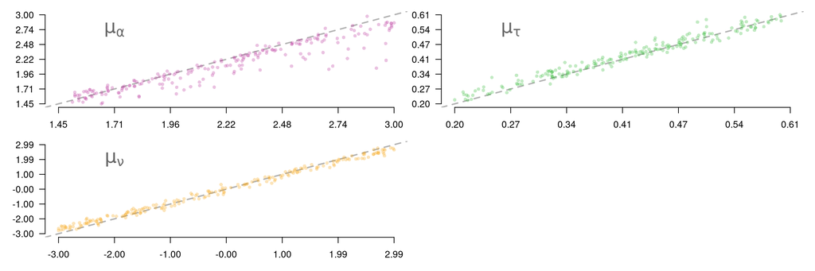

```r
plot_recovery(simM2)
```

### T-test model

```r
simT2 <- HDDM_runSims(nParticipants = nParticipants,
                     nTrials = nTrials,
                     nDatasets = nDatasets,
                     n.iter = n.iter,
                     n.chains = n.chains,
                     n.burnin = n.burnin,
                     n.thin = n.thin,
                     fromPrior = FALSE,
                     output.folder = store_results_to,
                     Show = Show,
                     track_allParameters = track_allParameters,
                     rhatCheck = rhatCheck,
                     redo_if_bad_rhat = redo_if_bad_rhat,
                     modelType = "ttest")
```

```
## This simulation had been run before.
## Loading stored results: COMPLETE!
##  Running this simulation study took  37.13333 minutes.
## ~~~~~~~~~~~~~~~~~~~~~~~~~~~~~~~~~~~~~~~~~~~~~~~~!!!
## R-hat check (All parameters):
## No Rhat greater than 1.05
## ~~~~~~~~~~~~~~~~~~~~~~~~~~~~~~~~~~~~~~~~~~~~~~~~!!!
```

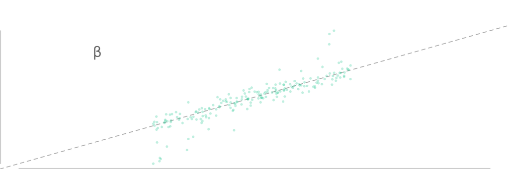

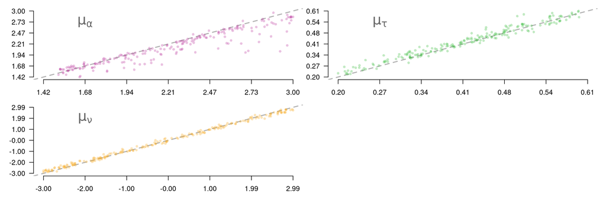

```r
plot_recovery(simT2)
```